# PG_10062022

[figure not shown]

Wayward Data Pipelines

Presentation: Marian Nehrebecki, Aleksander Partyga, Magdalena Sobala

Report: Marian Nehrebecki

The project consists of the following parts:

1. Business idea
2. Data Science
3. Preparation
4. Implementability
5. Conclusions

# 1. Business Idea

The problem is in regard to the architecture of the data storage and the goal is to improve the data solution that has the goal of executing critical data transfers between various parts of the company’s data storage architecture. The analysis focuses on the ETL process within the structure presented in Graph 1.

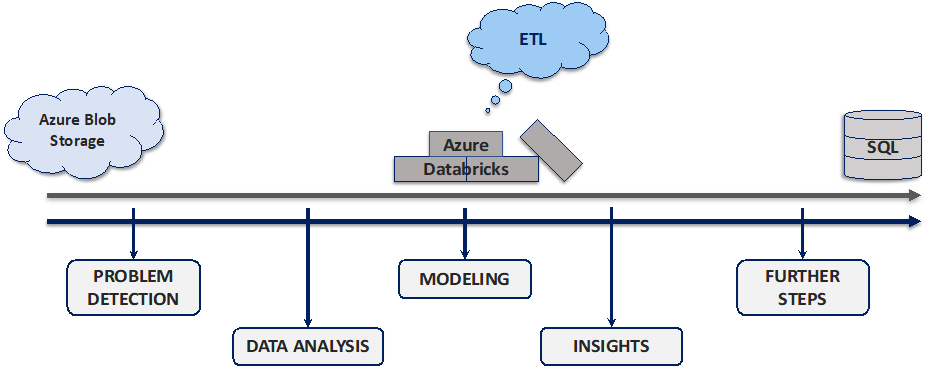

**Graph 1.** ETL process

The data was very limited, with the information solely on the time and cost of a single run of the pipeline as well as the amount of data processed in that run and its outcome - success or failure.

**Libraries**

```python
import pandas as pd
import numpy as np
import matplotlib.pyplot as plt
import seaborn as sns
from scipy.stats import chi2, stats

%matplotlib inline

import warnings
warnings.filterwarnings('ignore')
```

**Dataset**

```python
import os

df = pd.read_csv('/Users/nehrebeckiwp.pl/Desktop/understanding business/dataset.csv')
df.head(10)
```

|  | seconds_processing | MB_data_processed | dollars_run_cost | job_result |
| --- | --- | --- | --- | --- |
| 0 | 355.661078 | 233964.786450 | 90.901024 | successful |
| 1 | 423.391480 | 302949.983704 | 92.762539 | successful |
| 2 | 300.319488 | 136451.166213 | 77.929712 | successful |
| 3 | 514.272920 | 228745.842668 | 109.141386 | successful |
| 4 | 416.152489 | 73169.772809 | 97.857536 | successful |
| 5 | 209.088024 | 79675.694024 | 75.508739 | failed |
| 6 | 562.483672 | 369034.824649 | 98.936079 | successful |
| 7 | 545.587823 | 150053.467302 | 104.558782 | successful |
| 8 | 477.971019 | 368477.158272 | 85.847826 | failed |
| 9 | 274.545493 | 61053.934538 | 77.180004 | successful |

```python
df.shape
```

```
(2530, 4)
```

Which variables are available in the dataset?

```python
df.columns = df.columns.str.lower()
print(df.columns.values)
```

```
['seconds_processing' 'mb_data_processed' 'dollars_run_cost' 'job_result']
```

```python
df.info()
```

```
<class 'pandas.core.frame.DataFrame'>
RangeIndex: 2530 entries, 0 to 2529
Data columns (total 4 columns):
 #   Column              Non-Null Count  Dtype
---  ------              --------------  -----
 0   seconds_processing  2530 non-null   float64
 1   mb_data_processed   2530 non-null   float64
 2   dollars_run_cost    2530 non-null   float64
 3   job_result          2530 non-null   object
dtypes: float64(3), object(1)
memory usage: 79.2+ KB
```

Dataset a dataset containing information about 2530 runs of the data pipeline described in the architecture diagram. In this dataset, we have the following columns:

- “seconds_processing” – The number of seconds that the ETL pipeline has taken to run.
- “MB_data_processed” – Amount of MB that have been processed during the pipeline execution
- “dollars_run_cost” – Total cost of running the pipeline for that specific run
- “job_result” – Result of the ETL process, either ‘successful’ or ‘failed’. In cases that it failed, we can consider that the pipeline took all the specified time to run but for some problem during execution, it failed at the end, or the data was not transferred completely or accurately, in which case the pipeline run was of no use

# 2. Data science

This gives as a very narrow view of the problem - it is difficult to point out definitive causes of the failures, which account for 20% of the sample.

In order to realize the goal of the project the diagram presented in the Graph 2 was used.

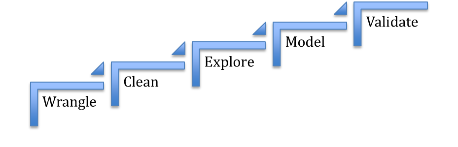

Working with data is usually a multiple iteration of the hypothesis - analysis - inference loop.

# 3. Preparation

**3.1. Data wrangling**

We check the target variable - job_result. Verification of the missing values.

```python
sum(df['job_result'].isna())
```

```
0
```

```python
df.job_result.value_counts(normalize = True)
```

```
successful    0.804743
failed        0.195257
Name: job_result, dtype: float64
```

```python
df.describe(include=['O'])
```

|  | job_result |
| --- | --- |
| count | 2530 |
| unique | 2 |
| top | successful |
| freq | 2036 |

The provided data was clean, it does not contain any missing values, so overall we can say that the dataset is prepared neatly; however, the sample was highly imbalanced - with the failure rate at 19.5%.

All features are numeric and have 6 decimal places. This number is more than needed, especially that we don't measure the cost in fraction of cents or time in fraction of seconds (in this case). Therefore, some rounding will be required to tidy the data.

What is the distribution of the values of numerical variables in samples?

```python
df.describe()
```

|  | seconds_processing | mb_data_processed | dollars_run_cost |
| --- | --- | --- | --- |
| count | 2530.000000 | 2530.000000 | 2530.000000 |
| mean | 383.943816 | 167535.330528 | 88.449280 |
| std | 98.504249 | 116622.516698 | 11.193201 |
| min | 50.000000 | 1764.000000 | 54.000000 |
| 25% | 313.409072 | 81421.272499 | 80.627097 |
| 50% | 381.165255 | 137917.764965 | 87.632533 |
| 75% | 450.656159 | 227368.128957 | 95.676206 |
| max | 708.648018 | 833690.636892 | 135.378119 |

From a brief look at the data, we can conclude that the variable connected to weight could potentially not be normallny distributed as the mean and median are quite different.

**We add a new variable 'GB_data_processed' which is a transformation of the 'MB_data_processed' from MB to GB to make it more readable and we transform dollars to average pln**

```python
#Create a new column for the amount of GB processed
df['GB_data_processed'] = df['mb_data_processed']/1000
#Create a new column for the PLN value
df['pln_run_cost'] = df['dollars_run_cost']*4.30 #average ex rate in april 22 acc to NBP mid-day rates
```

```python
df.head()
```

|  | seconds_processing | mb_data_processed | dollars_run_cost | job_result | GB_data_processed | pln_run_cost |
| --- | --- | --- | --- | --- | --- | --- |
| 0 | 355.661078 | 233964.786450 | 90.901024 | successful | 233.964786 | 390.874403 |
| 1 | 423.391480 | 302949.983704 | 92.762539 | successful | 302.949984 | 398.878920 |
| 2 | 300.319488 | 136451.166213 | 77.929712 | successful | 136.451166 | 335.097763 |
| 3 | 514.272920 | 228745.842668 | 109.141386 | successful | 228.745843 | 469.307959 |
| 4 | 416.152489 | 73169.772809 | 97.857536 | successful | 73.169773 | 420.787406 |

```python
#Delete unnecessary variables
del df['dollars_run_cost']
del df['mb_data_processed']
```

**3.2. Data correction**

Data correction we use when we would like to replace missing values. In our case there is no missing values.

```python
df = df.fillna(np.nan)
```

**3.3. EDA**

Exploratory Data Analysis refers to the critical process of performing preliminary data research to detect patterns, detect anomalies, test hypotheses, and check assumptions with summary statistics and graphical representations.

*The greatest value of a picture is when it forces us to notice what we never expected to see.* John W. Tukey, Exploratory Data Analysis, 1977.

```
successful    2036
failed         494
Name: job_result, dtype: int64
```

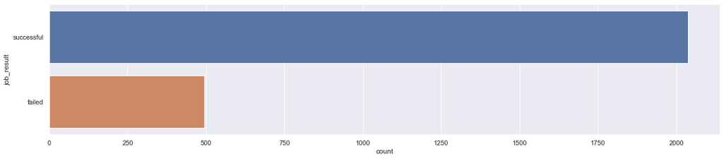

```python
#How many pipelines end with the failure?
fig = plt.figure(figsize=(20,4))
sns.countplot(y='job_result', data=df);
print(df.job_result.value_counts())
```

The failure rate equals 19.5%.

```python
df['job_result'] = df.job_result.astype('category')
```

```python
df['job_result'] = df.job_result.map({'successful':0, 'failed':1}).astype('int')
```

The analysis of features.

```python
#Graph for continuous variables
def n_plot(df, feature_name, target_name, palettemap, hue_order, feature_scale):
    df['Counts'] = ""
    fig, [axis0,axis1] = plt.subplots(1,2,figsize=(10,5))
    sns.distplot(df[feature_name], ax=axis0);
    sns.violinplot(x=feature_name, y="Counts", hue=target_name, hue_order=hue_order, data=df,
                   palette=palettemap, split=True, orient='h', ax=axis1)
    axis1.set_xticks(feature_scale)
    plt.show()

#Graph for Categorical/Ordinal variables
def c_plot(df, feature_name, target_name, palettemap):
    fig, [axis0,axis1] = plt.subplots(1,2,figsize=(10,5))
    df[feature_name].value_counts().plot.pie(autopct='%1.1f%%',ax=axis0)
    sns.countplot(x=feature_name, hue=target_name, data=df,
                  palette=palettemap,ax=axis1)
    plt.show()


palette = {0: "green", 1: "red"}
```

*GB_data_processed*

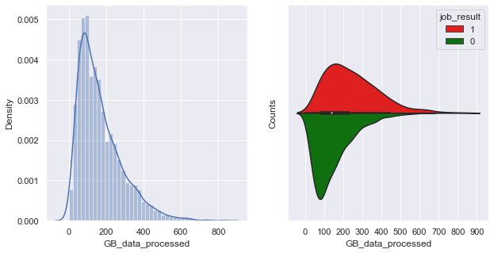

```python
n_plot(df, 'GB_data_processed', 'job_result', palette, [1, 0], range(0,1000,100))
```

**Graph 3.** Graph for weight (GB_data_processed)

The histogram is right skewed. GB distributions by job_result are not similar. The variable should have a discriminatory power.

The data includes untypical observations (see Graph 3). Due to the above, the given variable has been categorized (GB_cat).

```python
df['GB_cat'] = pd.cut(df['GB_data_processed'],bins=[0,250,400,600], labels=['small_GB','medium_GB','high_GB'])
```

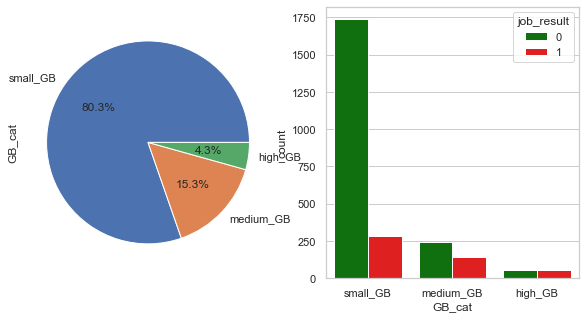

```python
c_plot(df, 'GB_cat','job_result', palette)
```

**Graph 4.** Graph for weight (GB_cat)

From the Graph 4 we conclude that 80.3% is small_GB. In the case of small_GB and medium_GB, it definitely outweighs job_result, which succeeds. On the other hand, in the case of high_GB, working in a random way can end in success or failure.

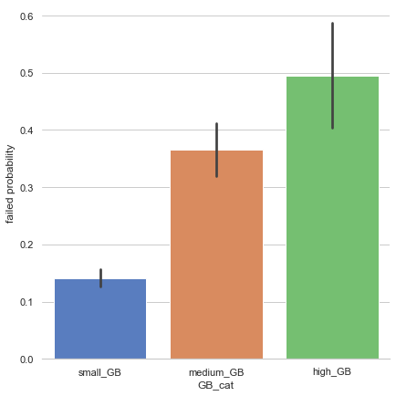

```python
sns.set(style="whitegrid")
#Nested bar chart to show failed for GB_cat
g = sns.catplot(x="GB_cat", y="job_result", data=df,
                height=6, kind="bar", palette="muted")
g.despine(left=True)
g.set_ylabels("failed probability")
```

**Graph 5.** Failed probability by weight (GB_cat)

We observe that for category small_GB we have the lowest failed probability and the highest failed probability for the high_GB category.

*pln_run_cost*

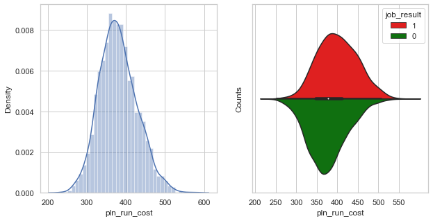

```python
n_plot(df, 'pln_run_cost', 'job_result', palette, [1, 0], range(200,600,50))
```

**Graph 6.** Graph for cost (pln_run_cost)

The histogram is more symmetrical. Pln_run_cost distributions by job_result are more similar. The variable may not be discriminatory. The data includes untypical observations (see Graph 6). Due to the above, the given variable has been categorized (PLN_cat).

```python
df['PLN_cat'] = pd.cut(df['pln_run_cost'],bins=[200,400,450,500], labels=['small_PLN','medium_PLN','high_PLN'])
```

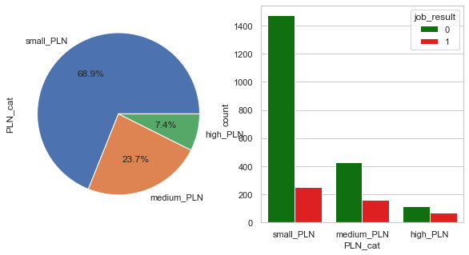

```python
c_plot(df, 'PLN_cat','job_result', palette)
```

**Graph 7.** Graph for cost (pln_run_cost)

Based on the Graph 7, we observe that 68.9% is small_PLN. In the case of small_PLN job_result, it is almost always successful.

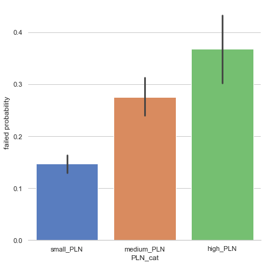

```python
sns.set(style="whitegrid")

g = sns.catplot(x="PLN_cat", y="job_result", data=df,
                height=6, kind="bar", palette="muted")
g.despine(left=True)
g.set_ylabels("failed probability")
```

**Graph 8.** Failed probability by cost (pln_run_cost)

For a categorized variable, the discriminant power increases. We observe for the smal_PLN category we have the lowest failed probability and for the high_PLN category we have the highest failed prabobility.

*seconds_processing*

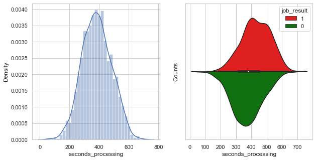

```python
n_plot(df, 'seconds_processing', 'job_result', palette, [1, 0], range(0,800,100))
```

**Graph 9.** Graph for runtime (seconds_processing)

The histogram is more symmetrical. The distributions of second_processing by job_result are less similar, the mean of seconds_processing by job_result = 1 is greater than that of job_result = 0. A variable may have a discriminatory power. The data includes untypical observations (see Graph 9). Due to the above, the given variable has been categorized (SEC_cat).

```python
df['SEC_cat'] = pd.cut(df['seconds_processing'],bins=[0,350,450,600], labels=['small_SEC','medium_SEC','high_SEC'])
```

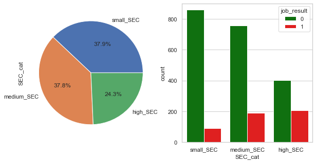

```python
c_plot(df, 'SEC_cat','job_result', palette)
```

**Graph 10.** Graph for runtime (seconds_processing)

Based on the Graph 10, we observe that small_SEC and medium_SEC are about 38% each. Small_SEC by job_result almost always succeeds.

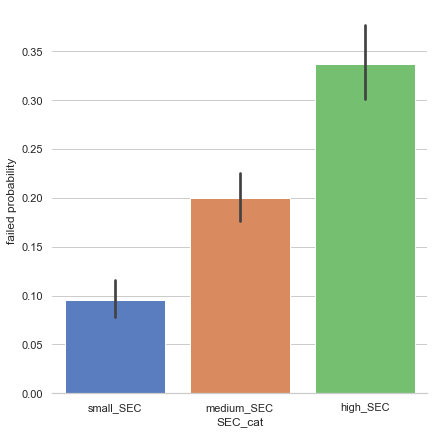

```python
sns.set(style="whitegrid")

g = sns.catplot(x="SEC_cat", y="job_result", data=df,
                height=6, kind="bar", palette="muted")
g.despine(left=True)
g.set_ylabels("failed probability")
```

**Graph 11.** Failed probability by runtime (seconds_processing)

For a categorized variable, the discriminant power increases. We observe for the smal_SEC category we have the lowest failed probability and for the high_SEC category we have the highest failed probability.

**3.4. Create dummies**

We define dummies variables for features.

```python
df.columns.values
```

```
array(['seconds_processing', 'job_result', 'GB_data_processed',
       'pln_run_cost', 'Counts', 'GB_cat', 'PLN_cat', 'SEC_cat'],
      dtype=object)
```

```python
df_dumm = df['job_result']
to_dummies = ['GB_cat','PLN_cat', 'SEC_cat']
for item in to_dummies:
    df_dumm = pd.concat([df_dumm, pd.get_dummies(df[item])], axis=1)
```

```python
df_dumm.columns.values
```

```
array(['job_result', 'small_GB', 'medium_GB', 'high_GB', 'small_PLN',
       'medium_PLN', 'high_PLN', 'small_SEC', 'medium_SEC', 'high_SEC'],
      dtype=object)
```

Created datasets we save as a file csv.

```python
df_dumm.to_csv('dumm.csv',index=False)
```

```python
df_num = df[['job_result', 'GB_data_processed', 'pln_run_cost', 'seconds_processing']]
```

```python
df_num.to_csv('num.csv',index=False)
```

```python
df_cat = df[['GB_cat', 'PLN_cat', 'SEC_cat']]
```

```python
df_cat.to_csv('cat.csv',index=False)
```

**3.5. What are the dependencies between the different variables?**

Initial informations about created datasets.

```python
dfn = pd.read_csv('num.csv')
dfc = pd.read_csv('cat.csv')
dfd = pd.read_csv('dumm.csv')
```

```python
dfn.info()
```

```
<class 'pandas.core.frame.DataFrame'>
RangeIndex: 2530 entries, 0 to 2529
Data columns (total 4 columns):
 #   Column              Non-Null Count  Dtype
---  ------              --------------  -----
 0   job_result          2530 non-null   int64
 1   GB_data_processed   2530 non-null   float64
 2   pln_run_cost        2530 non-null   float64
 3   seconds_processing  2530 non-null   float64
dtypes: float64(3), int64(1)
memory usage: 79.2 KB
```

```python
dfc.info()
```

```
<class 'pandas.core.frame.DataFrame'>
RangeIndex: 2530 entries, 0 to 2529
Data columns (total 3 columns):
 #   Column   Non-Null Count  Dtype
---  ------   --------------  -----
 0   GB_cat   2516 non-null   object
 1   PLN_cat  2502 non-null   object
 2   SEC_cat  2503 non-null   object
dtypes: object(3)
memory usage: 59.4+ KB
```

```python
dfc.columns.values
```

```
array(['GB_cat', 'PLN_cat', 'SEC_cat'], dtype=object)
```

```python
dfn.columns.values
```

```
array(['job_result', 'GB_data_processed', 'pln_run_cost',
       'seconds_processing'], dtype=object)
```

```python
df = pd.concat([dfn, dfc], axis=1)
```

```python
df.columns.values
```

```
array(['job_result', 'GB_data_processed', 'pln_run_cost',
       'seconds_processing', 'GB_cat', 'PLN_cat', 'SEC_cat'], dtype=object)
```

*GB_cat*

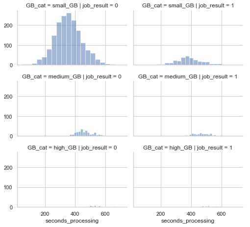

```python
grid = sns.FacetGrid(df, col='job_result', row='GB_cat', height=2.2, aspect=1.6)
grid.map(plt.hist, 'seconds_processing', alpha=.5, bins=20)
grid.add_legend();
```

**Graph 12.** Distribution of runtime by GB_cat and target.

We are most interested in the differences between job_results with success and job_results with failed. Note that the schedules are significantly different for seconds_processing by small_GB. In other cases, the distributions are similar. It would be interesting to see in more detail what worked here that the small_GB is so differentiated.

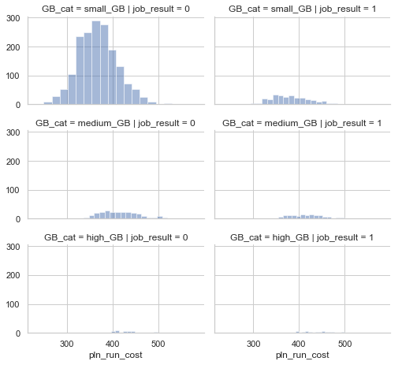

```python
grid = sns.FacetGrid(df, col='job_result', row='GB_cat', height=2.2, aspect=1.6)
grid.map(plt.hist, 'pln_run_cost', alpha=.5, bins=20)
grid.add_legend();
```

**Graph 13.** Distribution of cost by GB_cat and target.

Note that the schedules are significantly different for pln_run_cost like for seconds_processing by small_GB. In other cases, the distributions are similar. It would be interesting to see in more detail what worked here that the small_GB is so differentiated.

*PLN_cat*

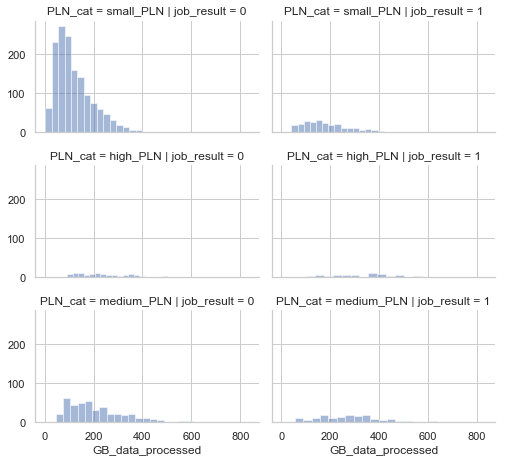

```python
grid = sns.FacetGrid(df, col='job_result', row='PLN_cat', height=2.2, aspect=1.6)
grid.map(plt.hist, 'GB_data_processed', alpha=.5, bins=20)
grid.add_legend();
```

**Graph 14.** Distribution of weight by PLN_cat and target.

Note that the schedules are significantly different for GB by small_PLN. In other cases, the distributions are similar. It would be interesting to see in more detail what worked here that the small_PLN is so differentiated.

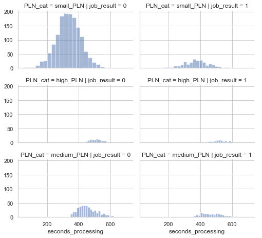

```python
grid = sns.FacetGrid(df, col='job_result', row='PLN_cat', height=2.2, aspect=1.6)
grid.map(plt.hist, 'seconds_processing', alpha=.5, bins=20)
grid.add_legend();
```

**Graph 15.** Distribution of runtime by PLN_cat and target.

Note that the schedules are significantly different for seconds_processing line for GB by small_PLN. In other cases, the distributions are similar. It would be interesting to see in more detail what worked here that the small_PLN is so differentiated.

*SEC_cat*

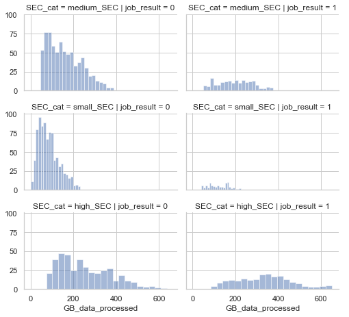

```python
grid = sns.FacetGrid(df, col='job_result', row='SEC_cat', height=2.2, aspect=1.6)
grid.map(plt.hist, 'GB_data_processed', alpha=.5, bins=20)
grid.add_legend();
```

**Graph 16.** Distribution of weight by SEC_cat and target.

Note that the schedules are significantly different for GB by medium_SEC i small_SEC. In other cases, the distributions are similar. It would be interesting to see in more detail what worked here that the medium_SEC i small_SEC are so differentiated.

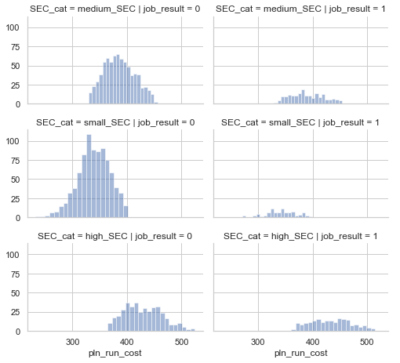

```python
grid = sns.FacetGrid(df, col='job_result', row='SEC_cat', height=2.2, aspect=1.6)
grid.map(plt.hist, 'pln_run_cost', alpha=.5, bins=20)
grid.add_legend();
```

**Graph 17.** Distribution of cost by SEC_cat and target.

Note that the schedules are significantly different for pln_run_cost like for GB by medium_SEC i small_SEC. In other cases, the distributions are similar. It would be interesting to see in more detail what worked here that the medium_SEC i small_SEC are so differentiated.

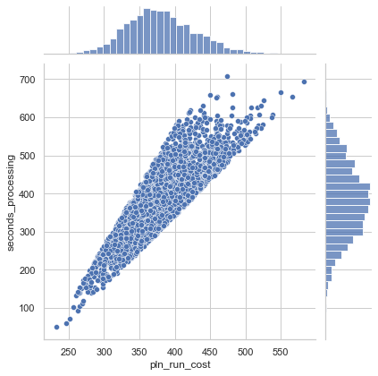

```python
sns.jointplot('pln_run_cost', 'seconds_processing', df)
```

**Graph 18.** Joint plot between 'pln_run_cost' and 'seconds_processing'

We have a rather linear relationship between runtime and cost, with the variation increasing for higher runtimes.

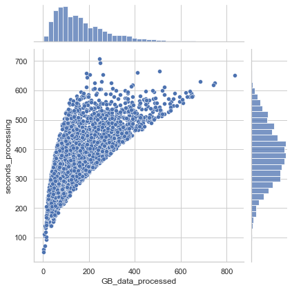

```python
sns.jointplot('GB_data_processed', 'seconds_processing', df)
```

**Graph 19.** Joint plot between 'GB_data_processed' and 'seconds_processing'

We can see that we have the most observations with low GBs. The distribution of the runtime variable shows that the most observations were between 350-450 seconds.

There is a sort of an exponential relationship between runtime and GBs processed.

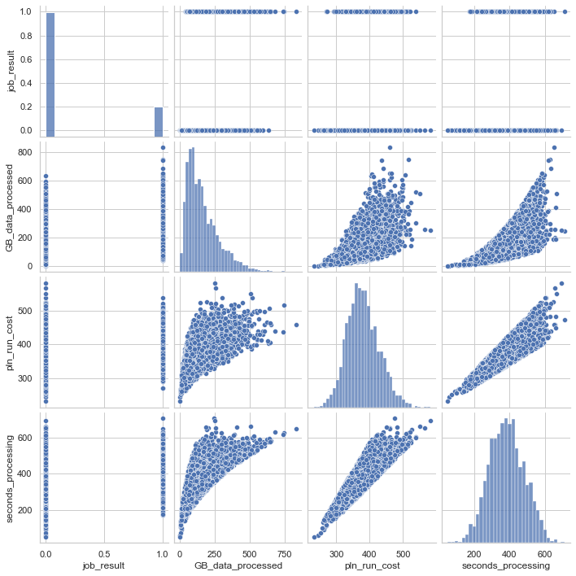

```python
sns.pairplot(dfn)
```

**Graph 20.** Pair plot

Summary of most important relations between explanatory variables:

- The longer the processing time and the bigger the amount of data the higher the cost of using the Azure services.
- The bigger the dataset the longer the processing time.

Summary of most important relations between explanatory variables and dependent variable:

- The distributions of dependent variables vary among each other for the two outcome groups: 1) processes that succeeded and 2) processes that failed.
- The ones which failed took on average more time, were more expensive, but most importantly had bigger weight (in terms of GB). The median for the success group was circa 122 GB, while for the failure group 221 GB.

**3.6. Correlation check**

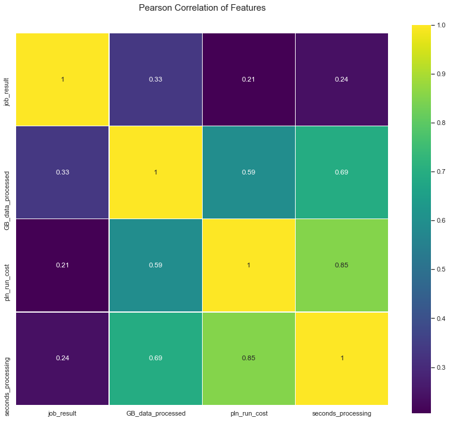

```python
colormap = plt.cm.viridis
plt.figure(figsize=(14,12))
plt.title('Pearson Correlation of Features', y=1.05, size=15)
sns.heatmap(dfn.astype(float).corr(),linewidths=0.1,vmax=1.0,
            square=True, cmap=colormap, linecolor='white', annot=True)
```

**Table 1.** Pearson Correlation of Features

It is worth noting that taking into account all the variables is usually not the best way to get a good result in the ML approach.Correlation testing is not sufficient to expertly decide which variable to discard and which to keep in the model.

**3.7. Performing a selection of variables**

We use the next technics to select features:

```
    1. Variance Threshold
    2. Univariate feature selection
    3. Recursive feature elimination
    4. SelectFromModel
    5. Feature importance
```

**1. Variance Threshold**: this is the removal of variables whose variance does not reach a certain threshold.

```python
from sklearn.feature_selection import VarianceThreshold

mdlsel = VarianceThreshold(threshold=0.1)
mdlsel.fit(dfd)
ix = mdlsel.get_support()

df_VT = pd.DataFrame(mdlsel.transform(dfd), columns = dfd.columns.values[ix])
selected_VT = dfd.columns.values[ix]
print(selected_VT)
```

```
['job_result' 'small_GB' 'medium_GB' 'small_PLN' 'medium_PLN' 'small_SEC'
 'medium_SEC' 'high_SEC']
```

**2. Univariate**: selects the best variables based on one-dimensional statistical tests.

```python
from sklearn.feature_selection import SelectKBest
from sklearn.feature_selection import chi2

X = dfd.drop('job_result',axis=1)
y = dfd['job_result']

mdlsel = SelectKBest(chi2, k=8)
mdlsel.fit(X,y)
ix = mdlsel.get_support()
df_SB = pd.DataFrame(mdlsel.transform(X), columns = X.columns.values[ix])
selected_SB = X.columns.values[ix]
print(selected_SB)
```

```
['small_GB' 'medium_GB' 'high_GB' 'small_PLN' 'medium_PLN' 'high_PLN'
 'small_SEC' 'high_SEC']
```

```python
from sklearn.feature_selection import GenericUnivariateSelect
X = dfd.drop('job_result',axis=1)
y = dfd['job_result']
transformer = GenericUnivariateSelect(chi2, 'k_best', param=8)
transformer.fit(X,y)
ix = transformer.get_support()
df_GUS = pd.DataFrame(transformer.transform(X), columns = X.columns.values[ix])
selected_GUS = X.columns.values[ix]
print(selected_GUS)
```

```
['small_GB' 'medium_GB' 'high_GB' 'small_PLN' 'medium_PLN' 'high_PLN'
 'small_SEC' 'high_SEC']
```

**3. Recursive feature elimination** given an external estimator that assigns weights to features (e.g., coefficients of a linear model), recursive feature elimination (RFE) is the selection of features by recursively considering smaller and smaller sets of features.

```python
from sklearn.feature_selection import RFE
from sklearn.linear_model import LogisticRegression
linmdl = LogisticRegression()
X = dfd.drop('job_result',axis=1)
y = dfd['job_result']
mdl = RFE(linmdl,n_features_to_select=8)
mdl.fit(X,y)
ix = mdl.get_support()
df_RFE = pd.DataFrame(mdl.transform(X), columns = X.columns.values[ix])
selected_RFE = X.columns.values[ix]
print(selected_RFE)
```

```
['small_GB' 'medium_GB' 'high_GB' 'small_PLN' 'high_PLN' 'small_SEC'
 'medium_SEC' 'high_SEC']
```

**4. SelectFromModel**: it's a meta-transformer.

```python
from sklearn.feature_selection import SelectFromModel

X = dfd.drop('job_result',axis=1)
y = dfd['job_result']

#Linear Model
linmdl = LogisticRegression()
linmdl.fit(X,y)
mdl = SelectFromModel(linmdl,prefit=True)
ix = mdl.get_support()
df_SFM = pd.DataFrame(mdl.transform(X), columns = X.columns.values[ix])
selected_SFM = X.columns.values[ix]
print(selected_SFM)
```

```
['small_GB' 'medium_GB' 'high_GB' 'small_SEC']
```

```python
from sklearn.ensemble import RandomForestClassifier

X = dfd.drop('job_result',axis=1)
y = dfd['job_result']
rf_checker = RandomForestClassifier()
rf_checker.fit(X, y)
importances_df = pd.DataFrame(rf_checker.feature_importances_, columns=['feature_importance'],
                              index=X.columns)
importances_df.sort_values(by=['feature_importance'], ascending=False, inplace=True)
print(importances_df)
```

```
            feature_importance
small_GB              0.365911
high_SEC              0.140405
medium_GB             0.122621
high_GB               0.088261
small_SEC             0.085646
small_PLN             0.062047
medium_PLN            0.052809
medium_SEC            0.041426
high_PLN              0.040873
```

**3.8. Interaction of variables**

Based on the last section we choose features. Let's analyze whether we should include in our model interaction of the features. To realize this goal we use ML approach: CatBoost.

**Built samples**

We define target variable and features.

```python
from sklearn.model_selection import train_test_split
#Input and output DATA
target = dfd['job_result']
features = dfd[selected_GUS]

#Built samples
X_train,X_test,y_train,y_test = train_test_split(features,target,test_size=0.3,random_state=13)
```

**CatBoost**

We check whether it is worth adding interactions in the model. To answer this question, the model needs to be estimated. We start with CatBoost model that works well in practice. This is an analogue of XGBoost, but we can also use caterized variables.

```python
import shap
from sklearn.model_selection import GroupKFold
from sklearn.metrics import roc_curve, auc
from catboost import CatBoostClassifier, Pool, cv

import ppscore as pps
```

```python
params = {
         #IMPORTANT PARAMETERS
         'iterations': 18,
         'learning_rate': 0.01, #0.05
         'depth': 7,

         #EXTRA PARAMETERS
         'l2_leaf_reg': 0.1,
#          'n_estimators': None,

         #CONTROL PARAMETERS
         'loss_function': 'Logloss',
         'verbose': True
}
```

```python
#Initialize CatBoostClassifier
model = CatBoostClassifier(
                           #IMPORTANT PARAMETERS
                           iterations=18, # SET THIS VALUE FROM THE PLOT
                           learning_rate=params['learning_rate'],
                           depth=params['depth'],
                           l2_leaf_reg=params['l2_leaf_reg'],

                           #CONTROL PARAMETERS
                           loss_function='Logloss',
                           custom_metric='AUC:hints=skip_train~false',
                           verbose=True
)

#Fit model - use_best_model=False as we don't want to use information from test set
model = model.fit(X_train, y_train, eval_set=(X_test, y_test), use_best_model=False)
```

```
0:	learn: 0.6890145	test: 0.6889662	best: 0.6889662 (0)	total: 2.07ms	remaining: 35.2ms
1:	learn: 0.6848126	test: 0.6847062	best: 0.6847062 (1)	total: 5.57ms	remaining: 44.5ms
2:	learn: 0.6809226	test: 0.6807752	best: 0.6807752 (2)	total: 7.12ms	remaining: 35.6ms
3:	learn: 0.6769989	test: 0.6767698	best: 0.6767698 (3)	total: 8.3ms	remaining: 29.1ms
4:	learn: 0.6731115	test: 0.6728332	best: 0.6728332 (4)	total: 9.67ms	remaining: 25.1ms
5:	learn: 0.6692927	test: 0.6689036	best: 0.6689036 (5)	total: 11ms	remaining: 22ms
6:	learn: 0.6654893	test: 0.6650762	best: 0.6650762 (6)	total: 12.9ms	remaining: 20.3ms
7:	learn: 0.6620494	test: 0.6616331	best: 0.6616331 (7)	total: 14ms	remaining: 17.6ms
8:	learn: 0.6584115	test: 0.6578921	best: 0.6578921 (8)	total: 16.6ms	remaining: 16.6ms
9:	learn: 0.6549508	test: 0.6543867	best: 0.6543867 (9)	total: 18.5ms	remaining: 14.8ms
10:	learn: 0.6514645	test: 0.6508568	best: 0.6508568 (10)	total: 19.8ms	remaining: 12.6ms
11:	learn: 0.6481306	test: 0.6474695	best: 0.6474695 (11)	total: 20.5ms	remaining: 10.3ms
12:	learn: 0.6448218	test: 0.6441059	best: 0.6441059 (12)	total: 21.5ms	remaining: 8.25ms
13:	learn: 0.6415314	test: 0.6407154	best: 0.6407154 (13)	total: 22.6ms	remaining: 6.46ms
14:	learn: 0.6383049	test: 0.6374886	best: 0.6374886 (14)	total: 24.1ms	remaining: 4.82ms
15:	learn: 0.6351435	test: 0.6343038	best: 0.6343038 (15)	total: 25.2ms	remaining: 3.16ms
16:	learn: 0.6320388	test: 0.6311592	best: 0.6311592 (16)	total: 26.8ms	remaining: 1.57ms
17:	learn: 0.6289963	test: 0.6280323	best: 0.6280323 (17)	total: 27.9ms	remaining: 0us

bestTest = 0.6280322733
bestIteration = 17
```

```python
history_test = pd.DataFrame({'test-AUC-mean': model.evals_result_['validation']['AUC'],
                             'train-AUC-mean': model.evals_result_['learn']['AUC']})
```

```python
history_test
```

|  | test-AUC-mean | train-AUC-mean |
| --- | --- | --- |
| 0 | 0.660060 | 0.641948 |
| 1 | 0.705446 | 0.683338 |
| 2 | 0.707515 | 0.682440 |
| 3 | 0.711675 | 0.682692 |
| 4 | 0.712167 | 0.682652 |
| 5 | 0.713251 | 0.682735 |
| 6 | 0.713076 | 0.682916 |
| 7 | 0.712693 | 0.682857 |
| 8 | 0.712748 | 0.683066 |
| 9 | 0.712934 | 0.683231 |
| 10 | 0.712485 | 0.683182 |
| 11 | 0.712485 | 0.683182 |
| 12 | 0.712354 | 0.683131 |
| 13 | 0.712616 | 0.683109 |
| 14 | 0.712562 | 0.683156 |
| 15 | 0.712649 | 0.683023 |
| 16 | 0.712529 | 0.683241 |
| 17 | 0.712529 | 0.683241 |

AUC for test sample for bestIteration is equal 0.71.

```python
pred_train = model.predict(X_train, prediction_type='Probability')[:,1]
pred_test = model.predict(X_test, prediction_type='Probability')[:,1]
target_predict=model.predict(X_test)
```

```python
shap.initjs()
```

**CatBoost built-in FeatureImportance**

```
<BarContainer object of 8 artists>
```

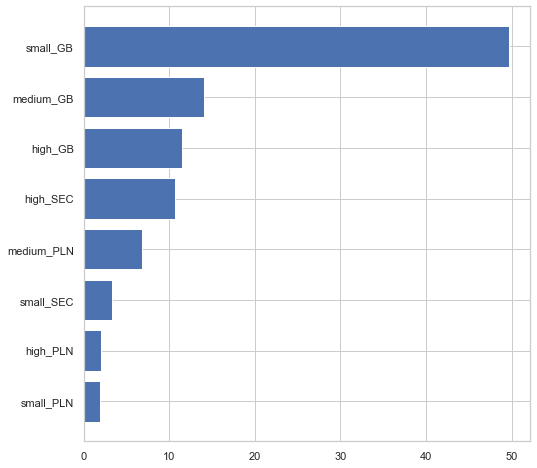

```python
feature_importance = model.get_feature_importance(type='FeatureImportance')
order = np.argsort(feature_importance)
feature_vals = np.flip(feature_importance[order])
feature_names = np.flip(X_train.columns[order])
plt.figure(figsize=(8,8))
plt.barh(np.flip(feature_names[:20]), np.flip(feature_vals[:20]))
```

**Graph 21.** Feature Importance statistics after CATBoost

Let's analyze the rating of the explanatory variables on the basis of the *FeatureImportance* statistics. Variables like *small_GB*, *medium_GB*, *high_GB*, *high_SEC*, *medium_PLN* are the main factors in CATBoost.

**SHAP values absolute values**

We compute a Shap value that helps to interpret the parameters in the ML approach.

```python
cv_dataset = Pool(data=X_train, label=y_train)
```

```python
shap_values = model.get_feature_importance(data=cv_dataset, type='ShapValues')
```

**CatBoost built-in Interactions**

```python
interaction = model.get_feature_importance(type='Interaction')
```

```python
fi_new = []
for k,item in enumerate(interaction):
    first = X_test.dtypes.index[interaction[k][0]]
    second = X_test.dtypes.index[interaction[k][1]]
    if first != second:
        fi_new.append([first + "_" + second, interaction[k][2]])

feature_score = pd.DataFrame(fi_new,columns=['Feature-Pair','Score']).head(20)
```

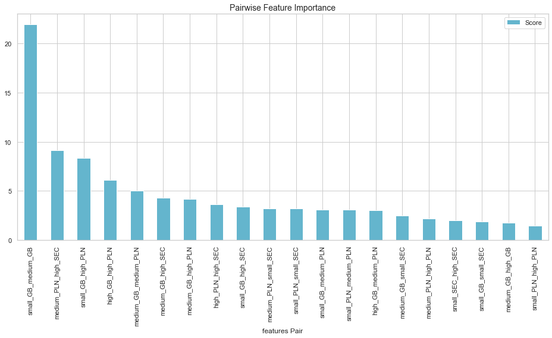

```python
feature_score = feature_score.sort_values(by='Score', ascending=False, inplace=False, kind='quicksort', na_position='last')
plt.rcParams["figure.figsize"] = (16,7)
ax = feature_score.plot('Feature-Pair', 'Score', kind='bar', color='c')
ax.set_title("Pairwise Feature Importance", fontsize = 14)
ax.set_xlabel("features Pair")
plt.show()
```

**Graph 22.** Pairwise Feature Importance

On the basis of the obtained results, it would be worth taking into account the interactions in the model.

```python
shap_values = model.get_feature_importance(data=cv_dataset, type='ShapValues')
expected_value = shap_values[0,-1] # last value in column - expected
shap_values = shap_values[:,:-1] # all rows and all cols without last
#print(expected_value, shap_values)
```

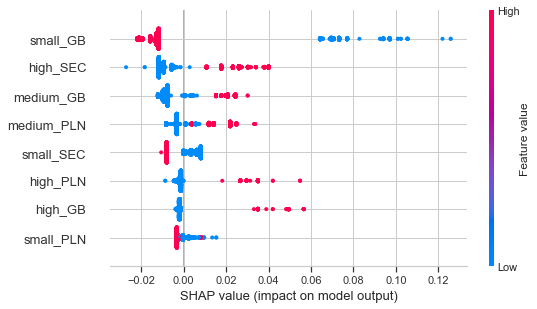

```python
shap.summary_plot(shap_values, X_train)
```

**Graph 23.** SHAP value (impact on model output)

- If small_GB = 1, this is associated with a decrease in failed probability.
- If high_SEC = 0, this is associated with a decrease in failed probability.
- If medium_GB = 0, this is associated with a decrease in failed probability.
- If medium_PLN = 0, this is associated with a decrease in failed probability.
- If small_SEC = 1, this is associated with a decrease in failed probability.
- If high_PLN = 0, this is associated with a decrease in failed probability.

```python
print(model.get_best_score())
print(model.get_best_iteration())

acc_cat = accuracy_score(y_test,target_predict)
print("Perceptron score: ", acc_cat)
```

```
{'learn': {'Logloss': 0.628996276183343, 'AUC': 0.6833381545281205}, 'validation': {'Logloss': 0.6280322733061854, 'AUC': 0.7132512315270936}}
17
Perceptron score:  0.8102766798418972
```

**CATBoost:**

TEST SAMPLE:  
AUC: 0.7132512315270936  
Perceptron score: 0.8102766798418972

[figure not shown]

```python
import seaborn as sns
from sklearn.metrics import confusion_matrix
confusion_matrix = confusion_matrix(y_test, target_predict)
plt.figure(figsize = (8,6))
sns.heatmap(confusion_matrix, annot=True, fmt="d")
```

**Table 2.** Confusion matrix after CATBoost, cuttoff=0.5

Based on the confusion matrix, we obtained TP statistics onli 6% if we use cutoff equal 0.5.

```python
dfd1=dfd.copy()
dfd1['small_GB_medium_SEC'] = dfd1['small_GB']*dfd1['medium_SEC']
dfd1['medium_GB_medium_PLN'] = dfd1['medium_GB']*dfd1['medium_PLN']
dfd1['high_PLN_high_SEC'] = dfd1['high_PLN']*dfd['high_SEC']
dfd1['medium_GB_high_PLN'] = dfd1['medium_GB']*dfd1['high_PLN']
dfd1['high_GB_medium_PLN'] = dfd1['high_GB']*dfd1['medium_PLN']
dfd1['small_GB_medium_GB'] = dfd1['small_GB']*dfd1['medium_GB']
```

## 4. Implementability

**4.1. Selection of the model without interaction**

Based on the results of the preliminary estimation using the ML: CatBoost approach, let's try to perform alternative models in order to improve the obtained results.

```
    - Logistic Regression
    - Support Vector Machine
    - K-nearest neigbors
    - Naive Bayes Classifier
    - Decision Tree
    - Random Forest
    - Perceptron
    - Stochastic Gradient Descent
```

```python
from sklearn.linear_model import LogisticRegression
from sklearn.model_selection import train_test_split
from sklearn.metrics import accuracy_score
from sklearn.metrics import mean_squared_error, r2_score

#Input and output data
target = dfd['job_result']
features = dfd[selected_GUS]
#Construction of test and training sample
X_train,X_test,y_train,y_test = train_test_split(features,target,test_size=0.3,random_state=13)


LR = LogisticRegression(random_state=13)
LR_ = LR.fit(X_train,y_train)
target_predict=LR_.predict(X_test)

target_predict_prob = LR.predict_proba(X_test)[:,1]

#If we use 0.20 as the cutoff value
target_predict20=[1 if i > 0.20 else 0 for i in target_predict_prob]

print("TEST SAMPLE: ")
acc_log = accuracy_score(y_test,target_predict)
print("Logistic Regression Score: ", acc_log)

from sklearn.metrics import roc_auc_score
AUC_log=roc_auc_score(y_test, target_predict_prob)
print("AUC    :", AUC_log)

print ("MSE    :",mean_squared_error(y_test,target_predict))
```

```
TEST SAMPLE:
Logistic Regression Score:  0.8129117259552042
AUC    : 0.7144225506294473
MSE    : 0.18708827404479578
```

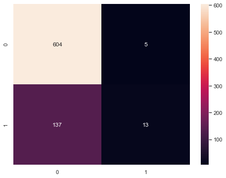

```python
import seaborn as sns
from sklearn.metrics import confusion_matrix
confusion_matrix = confusion_matrix(y_test, target_predict)
plt.figure(figsize = (8,6))
sns.heatmap(confusion_matrix, annot=True, fmt="d")
```

**Table 2.** Confusion matrix after logit regression, cuttoff=0.5

Based on the confusion matrix, we obtained better results for TP statistics than in CatBoost if we use cutoff equal 0.5.

### SVM - Suppor vector machine

```python
from sklearn.svm import SVC

target = dfd['job_result']
features = dfd[selected_GUS]
#Build test and training test
X_train,X_test,y_train,y_test = train_test_split(features,target,test_size=0.3,random_state=13)

svc = SVC(random_state=13, probability=True)
svc_ = svc.fit(X_train,y_train)
target_predict=svc_.predict(X_test)


target_predict_prob = svc_.predict_proba(X_test)[:,1]

print("TEST SAMPLE: ")
acc_svm = accuracy_score(y_test,target_predict)
print("SVM Score: ", acc_svm)

from sklearn.metrics import roc_auc_score
AUC_svm=roc_auc_score(y_test, target_predict_prob)
print("AUC      : ", AUC_svm)

print ("MSE      :",  mean_squared_error(y_test,target_predict))
```

```
TEST SAMPLE:
SVM Score:  0.8155467720685112
AUC      :  0.6117077175697866
MSE      : 0.1844532279314888
```

### KNN - K-nearest neighbours

```python
from sklearn.neighbors import KNeighborsClassifier

target = dfd['job_result']
features = dfd[selected_GUS]

X_train,X_test,y_train,y_test = train_test_split(features,target,test_size=0.3,random_state=13)

knn = KNeighborsClassifier(n_neighbors=5)
knn_ = knn.fit(X_train,y_train)
target_predict=knn_.predict(X_test)

target_predict_prob = knn_.predict_proba(X_test)[:,1]

print("TEST SAMPLE: ")

acc_knn = accuracy_score(y_test,target_predict)
print("KNN Score: ", acc_knn)

from sklearn.metrics import roc_auc_score
AUC_knn=roc_auc_score(y_test, target_predict_prob)
print("AUC: ", AUC_knn)

print ("MSE    :",mean_squared_error(y_test,target_predict))
```

```
TEST SAMPLE:
KNN Score:  0.8155467720685112
AUC:  0.5597099069512863
MSE    : 0.1844532279314888
```

### Naive Bayes

```python
from sklearn.naive_bayes import GaussianNB

target = dfd['job_result']
features = dfd[selected_GUS]

X_train,X_test,y_train,y_test = train_test_split(features,target,test_size=0.3,random_state=13)

gnb = GaussianNB()
gnb_ = gnb.fit(X_train,y_train)
target_predict=gnb_.predict(X_test)

target_predict_prob = gnb_.predict_proba(X_test)[:,1]

print("TEST SAMPLE: ")

acc_gaussian = accuracy_score(y_test,target_predict)
print("Naive Bayes Score: ", acc_gaussian)

from sklearn.metrics import roc_auc_score
AUC_gaussian=roc_auc_score(y_test, target_predict_prob)
print("AUC: ", AUC_gaussian)

print ("MSE    :",mean_squared_error(y_test,target_predict))
```

```
TEST SAMPLE:
Naive Bayes Score:  0.7602108036890646
AUC:  0.7085659551176793
MSE    : 0.23978919631093545
```

### Decision Tree

```python
from sklearn import tree

target = dfd['job_result']
features = dfd[selected_GUS]

#Construction of test and training sample
X_train,X_test,y_train,y_test = train_test_split(features,target,test_size=0.3,random_state=42)

decision_tree = tree.DecisionTreeClassifier(random_state=1,criterion = 'entropy',min_samples_split = 100)


decision_tree_ = decision_tree.fit(X_train,y_train)
target_predict=decision_tree_.predict(X_test)

target_predict_prob = decision_tree_.predict_proba(X_test)[:,1]

print("TEST SAMPLE: ")

acc_tree = accuracy_score(y_test,target_predict)
print("Decision tree score: ", acc_tree)

from sklearn.metrics import roc_auc_score
AUC_tree=roc_auc_score(y_test, target_predict_prob)
print("AUC: ", AUC_tree)

print ("MSE    :",mean_squared_error(y_test,target_predict))
```

```
TEST SAMPLE:
Decision tree score:  0.8287220026350461
AUC:  0.6664679916910585
MSE    : 0.1712779973649539
```

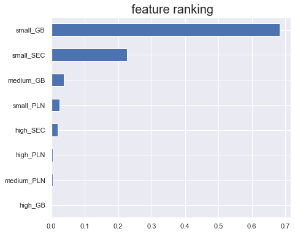

```python
sns.set()
feature_importances = pd.Series(decision_tree.feature_importances_, index = X_train.columns).sort_values()
#feature_importances.sort()
feature_importances.plot(kind = "barh", figsize = (7,6));
plt.title(" feature ranking", fontsize = 20)
plt.show()
```

**Graph 24.** Feature Importance statistics after Decision Tree

Let's analyze the rating of the explanatory variables on the basis of the FeatureImportance statistics. Variables like **small_GB**, **small_SEC**, **medium_GB**, **small_PLN**, **high_SEC** are the main factors in Decision Tree.

### Random Forest Classifier

```python
from sklearn.ensemble import RandomForestClassifier

target = dfd['job_result']
features = dfd[selected_GUS]

#Construction of test and training sample
X_train,X_test,y_train,y_test = train_test_split(features,target,test_size=0.3,random_state=13)

forest = RandomForestClassifier(max_depth=5, min_samples_split=10, n_estimators=500, random_state=5,criterion = 'entropy')


forest_ = forest.fit(X_train,y_train)
target_predict = forest_.predict(X_test)

target_predict_prob = forest_.predict_proba(X_test)[:,1]

print("TEST SAMPLE: ")

acc_forest = accuracy_score(y_test,target_predict)
print("Random forest score: ", acc_forest)


from sklearn.metrics import roc_auc_score
AUC_forest=roc_auc_score(y_test, target_predict_prob)
print("AUC: ", AUC_forest)

print ("MSE    :",mean_squared_error(y_test,target_predict))
```

```
TEST SAMPLE:
Random forest score:  0.8155467720685112
AUC:  0.7134592227695676
MSE    : 0.1844532279314888
```

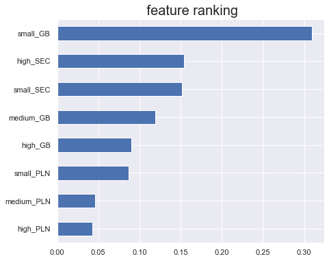

```python
sns.set()
feature_importances = pd.Series(forest.feature_importances_, index = X_train.columns).sort_values()
#feature_importances.sort()
feature_importances.plot(kind = "barh", figsize = (7,6));
plt.title(" feature ranking", fontsize = 20)
plt.show()
```

**Graph 25.** Feature Importance statistics after Random Forest

### Perceptron

```python
from sklearn.linear_model import Perceptron

target = dfd['job_result']
features = dfd[selected_GUS]

#Construction of test and training sample
X_train,X_test,y_train,y_test = train_test_split(features,target,test_size=0.3,random_state=13)

perceptron = Perceptron()
perceptron_ = perceptron.fit(X_train,y_train)
target_predict = perceptron_.predict(X_test)


acc_perceptron = accuracy_score(y_test,target_predict)

print("TEST SAMPLE: ")

print("Perceptron score: ", acc_perceptron)

from sklearn.metrics import roc_auc_score
AUC_perceptron=roc_auc_score(y_test, target_predict)
print("AUC: ", AUC_perceptron)

print ("MSE    :",mean_squared_error(y_test,target_predict))
```

```
TEST SAMPLE:
Perceptron score:  0.8050065876152833
AUC:  0.5594252873563219
MSE    : 0.19499341238471674
```